# Part II - Ford Gobike Sharing Data Analysis

## by Abiola Aderemi

## Investigation Overview

1. Generally, most bike rides lasted for 5 - 10 minutes, while subscribers rode for 10 - 15 minutes and 20 - 27 minutes for customers.
2. The duration of bike rides across time periods for subscribers was very consistent and did not vary widely like that of customers. This could be as a result of subscribers being the overhelming majority of riders.
3. Most bike trips were carried out during the weekday (Monday - Friday), with over 25,000 trips recorded. The peak day for bike rides was on Thursday - 35,000 trips. Saturday and Sunday recorded about 15,000 trips. This tallies with earlier analysis done on days of the month.

## Dataset Overview

This dataset contains bike rides around San Fransisco area in the month of February 2019. There are 183,412 bike trips with 4646 bikes and 329 stations in the dataset.

## What are the number of bike rides per time period?

### What are the number of bike rides per day?

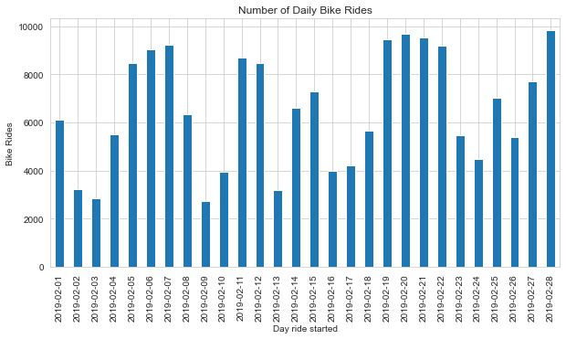

28/02/2019 (Thursday) had the most bike rides with almost 10,000 rides. 09/02/2019 (Saturday) had the least bike rides with about 2,500 rides.

Also, less than 1% of trips were carried over to the next day. This implies that further analysis on trips done on end days will be similar to that of start days.

### What are the number of bike rides per hour of the day?

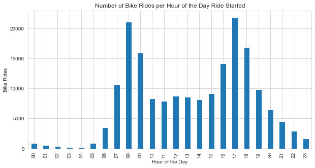

Peak bike ride activities had two peaks in the morning from the hours of 7am to 9am, with trips above 10,000 - 8am had above 20,000 trips.

Evening trips from the hours of 4pm to 6pm were also above 10,000 trips, with 5pm also having above 20,000 trips. This correlates with activity patterns of commuting to and from work.

### What are the number of bike rides per day of the week?

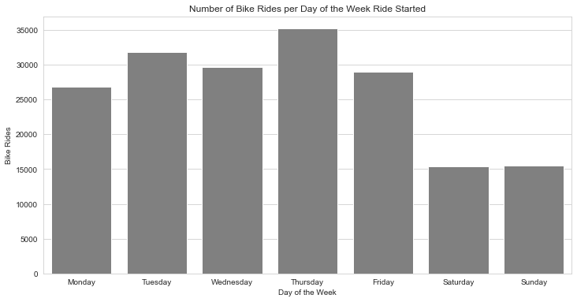

Most bike trips were carried out during the weekday (Monday - Friday), with over 25,000 trips recorded.

The peak day for bike rides was on Thursday - 35,000 trips. Saturday and Sunday recorded about 15,000 trips. This tallies with earlier analysis done on days of the month.

## Duration of Bike Rides per Time Period?

### Duration of Bike Rides per Day of the Month?

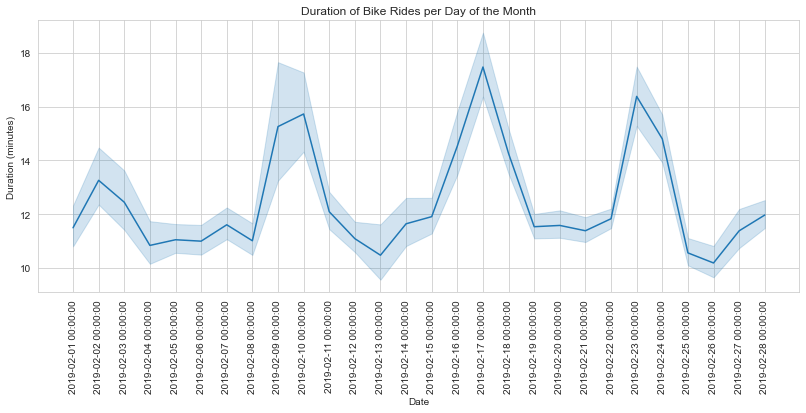

From the plot above, the peak ride duration were during the weekends, with the highest on the 17th of february 2019 having 17 minutes.

### Duration of Bike Rides per Day of the Week?

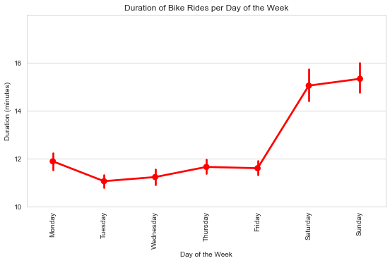

The trend of the ride durations rose to about 15 minutes on the weekend, Sunday being the highest, and fell to between 11 - 12 minutes during the weekday, Tuesday being the lowest.

### Duration of Bike Rides per Hour of the Day?

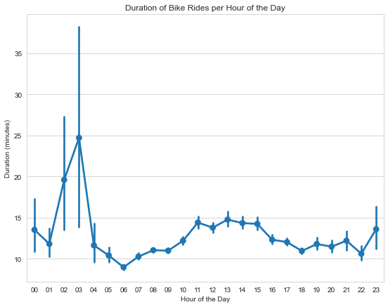

At 3am, the chart shows that about 25 minutes of cycling was done. This is quite curious and can be as a result of limited number of ride data at that hour.

### Member Gender breakdown of Bike Rides by Hour of the Day, Day of the Week and Day of the Month?

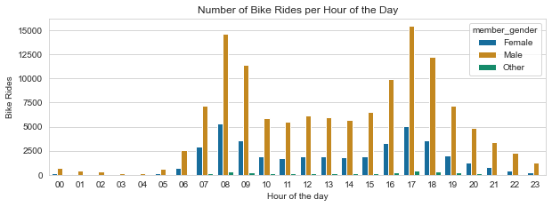

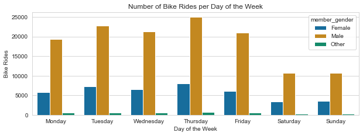

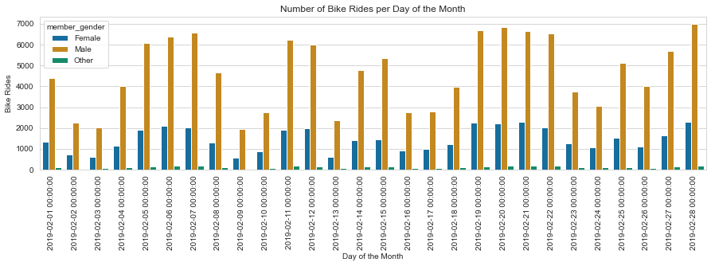

1. Further analysis on the bike rides in minutes per time period (hour of the day, day of the week and day of the month) shows a similar trend when it is further decomposed into the member_gender categories.
2. At 8am, there are about 5,000 bike rides by females, about 14,000 bike rides by males and less than 1,000 bike rides by other genders. At 5pm, there are about 5,000 bike rides by females, about 15,000 bike rides by males and less than 1,000 bike rides by other genders.
3. During weekdays which has its peak bike rides on Thursday's, 25,000 trips are made by males, while about 8,000 and 1,000 trips are made by females and other genders respectively.
4. On the 28th of february, 2019 about 7,000 bike rides were completed by males, with females and others completing about 2,000 and 300 trips respectively.

### User Type vs Duration (minutes) vs Member Gender?

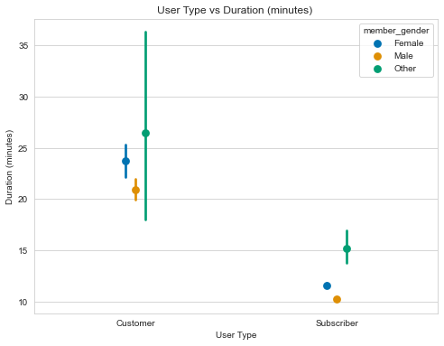

For each user type, the other gender had longer biker rides on average with 27 minutes and 15 minutes for customers and subscribers respectively.

### Ride Duration vs Time Periods vs User Type?

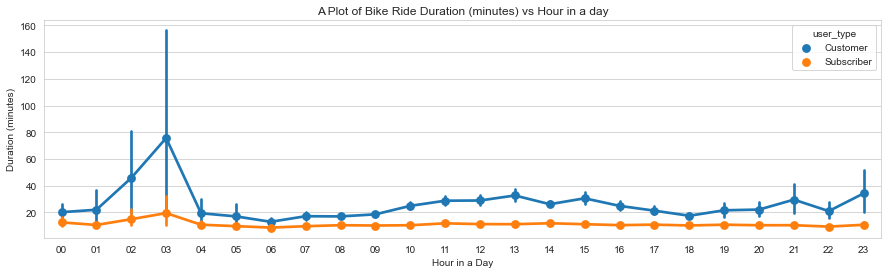

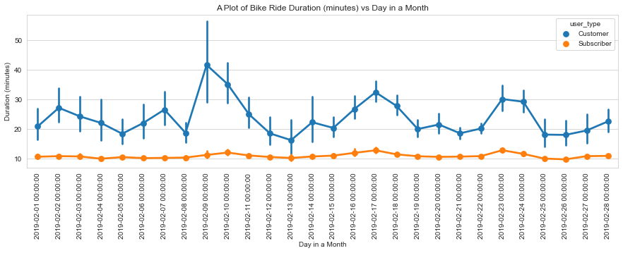

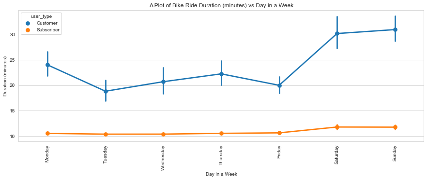

Customers generally had longer ride durations no matter the time periods.

# Thank you!

*Any Questions?*